# iphone2015-2018

Rachel Chang

2019/7/22

data source : https://zh-yue.wikipedia.org/wiki/IPhone

**安裝套件**

```r
library(bitops)
library(httr)
library(RCurl)
library(XML)
library(tm)
library(NLP)
library(tmcn)
library(jiebaRD)
library(jiebaR)
library(rvest)
library(stringr)
```

## 2018-9-12 iPhone XS,iPhone XS MAX；2018-10-26 iPhone XR

### 一、爬出ptt-iphone-mobliecomm文章標題

**遇到的困難:1.如何使用迴圈抓網頁標題?/2.抓取非html網址**

```r
library(rvest)
library(magrittr)

pttMobileComm <- data.frame()

for(id in 73:25) #2018.6.17-2018.12.30
{
  prefix <- "https://www.ptt.cc/bbs/MobileComm/search?page="
  url  <- paste0( prefix, as.character(id), "&q=iphone" )

  iphone <- read_html(url)
  post_title <- iphone%>%
    html_nodes(".title") %>%
    html_text()
  post_date <- iphone %>%
    html_nodes(".date") %>%
    html_text()

  pttMobileComm <- rbind(pttMobileComm, data.frame(title= post_title,
                                                    date= post_date))
}

library(knitr)
kable(head(pttMobileComm))
```

| title | date |
| --- | --- |
| Re: [討論] 為什麼HTC A9的假想敵會是IPHONE? | 6/26 |
| [討論] 為什麼HTC A9的假想敵會是IPHONE? | 6/26 |
| [新聞]蘋果史上最大電池容量手機 新iPhone將突破 | 6/26 |
| [新聞] 新 iPhone 降價的秘密？蘋果傳砍兩款「零 | 6/25 |
| [問題] 廣州iphone8 64g 4138人民幣可以買嗎 | 6/25 |
| [心得] iPhone 8 plus 不專業夜拍能力測試 | 6/24 |

### 二、統計所有文章標題有提到iPhone XS,iPhone XS MAX,iPhone XR的數量

**遇到的困難:1.篩選標題grepl/2.忽略大小寫ignore.case=TRUE**

```r
library(jiebaRD)
library(jiebaR)

cutter <- worker("tag")

# 自建字典
dic = c("iPhone XS","iPhone XS MAX", "iPhone XR")
new_user_word(cutter, dic)
```

```
## [1] TRUE
```

```r
a <- sapply(dic, grepl, pttMobileComm$title, ignore.case=TRUE)
b <- apply(a, 1, any)
library(knitr)
kable(head(pttMobileComm[b,]))
```

|  | title | date |
| --- | --- | --- |
| 143 | [新聞] 一支要390萬！超豪奢新iPhone XS搶先預購 | 8/17 |
| 201 | [新聞] 搶先看！iPhone XS新機實體現身 -【Tim】 | 9/03 |
| 218 | [新聞] 這就是「iPhone XS」？ | 8/31 |
| 241 | [情報] iPhone XR/Xs/XsMax 台灣價格 | 9/13 |
| 244 | [新聞] 蘋果官網不小心洩漏了 iPhone Xs、Xs Max | 9/12 |
| 263 | [閒聊] iPhone Xr價格多少才合理 | 9/13 |

### 三、依照month合併儲存

**遇到的困難:1.如何依照月份儲存資料/2.factor->string**

```r
library(dplyr)
library(lubridate)
iphone_data <- pttMobileComm[b,] %>%
  mutate(date=as.character(date)) %>%
  mutate(month= month(as.POSIXlt(date, format="%m/%d")))

library(knitr)
kable(head(iphone_data))
```

| title | date | month |
| --- | --- | --- |
| [新聞] 一支要390萬！超豪奢新iPhone XS搶先預購 | 8/17 | 8 |
| [新聞] 搶先看！iPhone XS新機實體現身 -【Tim】 | 9/03 | 9 |
| [新聞] 這就是「iPhone XS」？ | 8/31 | 8 |
| [情報] iPhone XR/Xs/XsMax 台灣價格 | 9/13 | 9 |
| [新聞] 蘋果官網不小心洩漏了 iPhone Xs、Xs Max | 9/12 | 9 |
| [閒聊] iPhone Xr價格多少才合理 | 9/13 | 9 |

```r
iphone_data1<-iphone_data%>%count(month)
iphone_2018 <- iphone_data1[-c(1),]
iphone_2018
```

```
## # A tibble: 5 x 2
##   month     n
##   <dbl> <int>
## 1     8     2
## 2     9   115
## 3    10   112
## 4    11    47
## 5    12    28
```

### 四、作圖

```r
t <- iphone_2018
colnames(t) <- c("month", "posts")
t
```

```
## # A tibble: 5 x 2
##   month posts
##   <dbl> <int>
## 1     8     2
## 2     9   115
## 3    10   112
## 4    11    47
## 5    12    28
```

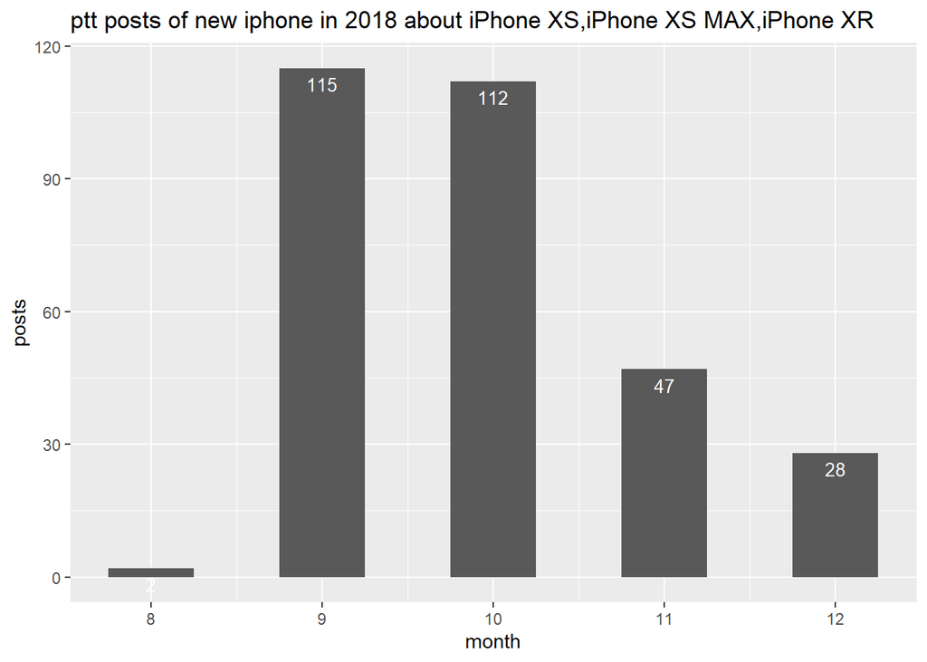

```r
library(ggplot2)
ggplot(data=t, aes(x=month,y=posts))+
       geom_bar(stat="identity",width=0.5)+
       ggtitle("ptt posts of new iphone in 2018 about iPhone XS,iPhone XS MAX,iPhone XR")+
       geom_text(aes(label=posts), vjust=1.6, color="white", size=3.5)
```

## 2017-9-12 iPhone 8,iphone 8 plus；2017-11-3 iPhone X

### 一、爬出ptt-iphone-mobliecomm文章標題

**遇到的困難:1.如何使用迴圈抓網頁標題?/2.抓取非html網址**

```r
library(magrittr)
library(rvest)

pttMobileComm_1 <- data.frame()

for(ids in 145:95) #2017.6.11-2017.12.30
{
  prefix <- "https://www.ptt.cc/bbs/MobileComm/search?page="
  url  <- paste0( prefix, as.character(ids), "&q=iphone" )

  iphone <- read_html(url)
  post_title <- iphone%>%
    html_nodes(".title") %>%
    html_text()
  post_date <- iphone %>%
    html_nodes(".date") %>%
    html_text()

  pttMobileComm_1 <- rbind(pttMobileComm_1, data.frame(title= post_title,
                                                    date= post_date))
}

library(knitr)
kable(head(pttMobileComm_1))
```

| title | date |
| --- | --- |
| Re: [新聞]【嗆聲片】iPhone早就遜掉了 他說hTC | 6/22 |
| Re: [新聞]【嗆聲片】iPhone早就遜掉了 他說hTC手機更 | 6/22 |
| Re: [新聞]【嗆聲片】iPhone早就遜掉了 他說hTC手機更 | 6/22 |
| [新聞] iPhone 上市十年 如何幫蘋果創造全球奇 | 6/22 |
| [新聞]【嗆聲片】iPhone早就遜掉了 他說hTC手機更 | 6/22 |
| [新聞] 一加5「撞臉」iPhone 7 Plus？劉作虎傷心 | 6/21 |

### 二、統計所有文章標題有提到iPhone X,iPhone 8,iphone 8 plus的數量

**遇到的困難:1.篩選標題grepl/2.忽略大小寫ignore.case=TRUE**

```r
library(jiebaRD)
library(jiebaR)

cutter <- worker("tag")

# 自建字典
dic1 = c("iPhone X","iPhone 8","iphone 8 plus")
new_user_word(cutter, dic1)
```

```
## [1] TRUE
```

```r
a1 <- sapply(dic1, grepl, pttMobileComm_1$title, ignore.case=TRUE)
b1 <- apply(a1, 1, any)

library(knitr)
kable(head(pttMobileComm_1[b1,]))
```

|  | title | date |
| --- | --- | --- |
| 10 | [問題] 中華平板到期,雙NP or 等IPHONE 8 綁約? | 6/21 |
| 12 | [新聞] 又是供應鏈爆料！iPhone 8 搭 AR 功能、 | 6/19 |
| 13 | [問題] 有推薦的安卓機或等iPhone 8? | 6/19 |
| 14 | [新聞] 緯創執行長爆料！確認 iPhone 8 將有這 2 | 6/16 |
| 19 | [情報] 真實 iPhone 8 玻璃面板與背板洩密照流出 | 6/13 |
| 23 | [情報] iPhone 8將有10w快速充電功能 | 6/29 |

### 三、依照month合併儲存

**遇到的困難:1.如何依照月份儲存資料/2.factor->string**

```r
library(dplyr)
library(lubridate)
iphone_data2 <- pttMobileComm_1[b1,] %>%
  mutate(date=as.character(date)) %>%
  mutate(month= month(as.POSIXlt(date, format="%m/%d")))

library(knitr)
kable(head(iphone_data2))
```

| title | date | month |
| --- | --- | --- |
| [問題] 中華平板到期,雙NP or 等IPHONE 8 綁約? | 6/21 | 6 |
| [新聞] 又是供應鏈爆料！iPhone 8 搭 AR 功能、 | 6/19 | 6 |
| [問題] 有推薦的安卓機或等iPhone 8? | 6/19 | 6 |
| [新聞] 緯創執行長爆料！確認 iPhone 8 將有這 2 | 6/16 | 6 |
| [情報] 真實 iPhone 8 玻璃面板與背板洩密照流出 | 6/13 | 6 |
| [情報] iPhone 8將有10w快速充電功能 | 6/29 | 6 |

```r
iphone_data3<-iphone_data2%>%count(month)
iphone_2017 <- iphone_data3[-c(1:3),]
iphone_2017
```

```
## # A tibble: 5 x 2
##   month     n
##   <dbl> <int>
## 1     8    13
## 2     9   125
## 3    10    84
## 4    11   122
## 5    12    44
```

### 四、作圖

```r
i <- iphone_2017
colnames(i) <- c("month", "posts")
i
```

```
## # A tibble: 5 x 2
##   month posts
##   <dbl> <int>
## 1     8    13
## 2     9   125
## 3    10    84
## 4    11   122
## 5    12    44
```

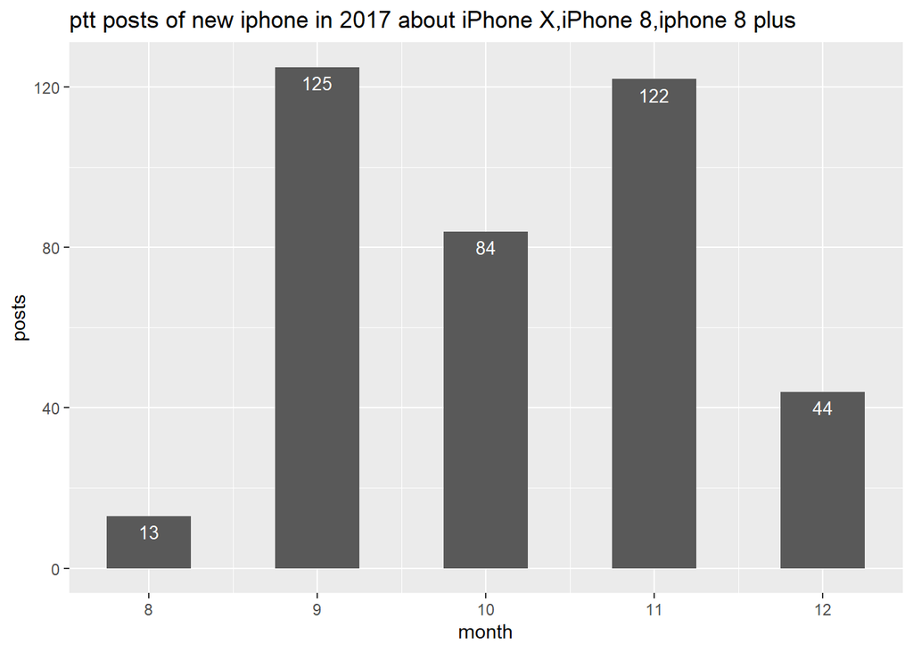

```r
library(ggplot2)
ggplot(data=i, aes(x=month,y=posts))+
       geom_bar(stat="identity",width=0.5)+
       ggtitle("ptt posts of new iphone in 2017 about iPhone X,iPhone 8,iphone 8 plus")+
       geom_text(aes(label=posts), vjust=1.6, color="white", size=3.5)
```

## 2016-9-7 iPhone 7,iPhone 7 Plus

### 一、爬出ptt-iphone-mobliecomm文章標題

**遇到的困難:1.如何使用迴圈抓網頁標題?/2.抓取非html網址**

```r
library(rvest)

pttMobileComm_2 <- data.frame()

for(idd in 15:8) #2016.6.7-2016.12.27
{
  prefix <- "https://www.ptt.cc/bbs/MobileComm/search?page="
  url  <- paste0( prefix, as.character(idd), "&q=iphone7" )

  iphone <- read_html(url)
  post_title <- iphone%>%
    html_nodes(".title") %>%
    html_text()
  post_date <- iphone %>%
    html_nodes(".date") %>%
    html_text()

  pttMobileComm_2 <- rbind(pttMobileComm_2, data.frame(title= post_title,
                                                    date= post_date))
}

library(knitr)
kable(head(pttMobileComm_2))
```

| title | date |
| --- | --- |
| [閒聊] 今年或許不會有iPhone7了 | 8/28 |
| [問題] iPhone7 vs HTC 10 vs Samsung note7 | 8/24 |
| Fw: [新聞] 蘋果聯合創辦人:iPhone7移除耳機孔將趕跑 | 8/24 |
| [新聞] 林志穎拿到iPhone7啦！ | 8/19 |
| [問題] HTC 10 v. S7E v. iPhone7 | 8/11 |
| Re: [情報] iphone7實機影片曝光? | 8/10 |

### 二、依照month合併儲存

**遇到的困難:1.如何依照月份儲存資料/2.factor->string**

```r
library(dplyr)
library(lubridate)
iphone_data4 <- pttMobileComm_2 %>%
  mutate(date=as.character(date)) %>%
  mutate(month= month(as.POSIXlt(date, format="%m/%d")))

library(knitr)
kable(head(iphone_data4))
```

| title | date | month |
| --- | --- | --- |
| [閒聊] 今年或許不會有iPhone7了 | 8/28 | 8 |
| [問題] iPhone7 vs HTC 10 vs Samsung note7 | 8/24 | 8 |
| Fw: [新聞] 蘋果聯合創辦人:iPhone7移除耳機孔將趕跑 | 8/24 | 8 |
| [新聞] 林志穎拿到iPhone7啦！ | 8/19 | 8 |
| [問題] HTC 10 v. S7E v. iPhone7 | 8/11 | 8 |
| Re: [情報] iphone7實機影片曝光? | 8/10 | 8 |

```r
iphone_data5<-iphone_data4%>%count(month)
iphone_2016 <- iphone_data5[-c(1:6),]
iphone_2016
```

```
## # A tibble: 5 x 2
##   month     n
##   <dbl> <int>
## 1     8    10
## 2     9    77
## 3    10    26
## 4    11    11
## 5    12    18
```

### 三、作圖

```r
j <- iphone_2016
colnames(j) <- c("month", "posts")
j
```

```
## # A tibble: 5 x 2
##   month posts
##   <dbl> <int>
## 1     8    10
## 2     9    77
## 3    10    26
## 4    11    11
## 5    12    18
```

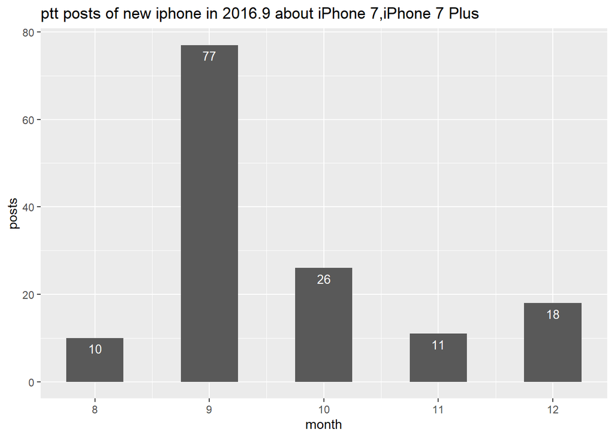

```r
library(ggplot2)
ggplot(data=j, aes(x=month,y=posts))+
       geom_bar(stat="identity",width=0.5)+
       ggtitle("ptt posts of new iphone in 2016.9 about iPhone 7,iPhone 7 Plus")+
       geom_text(aes(label=posts), vjust=1.6, color="white", size=3.5)
```

## 2016-3-21 iPhone SE

### 一、爬出ptt-iphone-mobliecomm文章標題

**遇到的困難:1.如何使用迴圈抓網頁標題?/2.抓取非html網址**

```r
library(rvest)

pttMobileComm_3 <- data.frame()

for(iD in 11:5) #2016.3.13-2016.8.25
{
  prefix <- "https://www.ptt.cc/bbs/MobileComm/search?page="
  url  <- paste0( prefix, as.character(iD), "&q=iphone+se" )

  iphone <- read_html(url)
  post_title <- iphone%>%
    html_nodes(".title") %>%
    html_text()
  post_date <- iphone %>%
    html_nodes(".date") %>%
    html_text()

  pttMobileComm_3 <- rbind(pttMobileComm_3, data.frame(title= post_title,
                                                    date= post_date))
}

library(knitr)
kable(head(pttMobileComm_3))
```

| title | date |
| --- | --- |
| Re: [新聞] iPhone SE售價曝光 傳450美元 | 3/14 |
| [新聞] iPhone SE售價曝光 傳450美元 | 3/13 |
| [情報] iPhone SE 效能跑分虐爆 Galaxy S7！ | 3/23 |
| Re: [情報] iPhone SE RAM 容量應為 2GB LPDDR4 | 3/23 |
| [情報] iPhone SE RAM 容量應為 2GB LPDDR4 | 3/23 |
| [閒聊] iPhone SE 發布會 天才小熊貓版 | 3/22 |

### 二、依照month合併儲存

**遇到的困難:1.如何依照月份儲存資料/2.factor->string**

```r
library(magrittr)
library(dplyr)
library(lubridate)
iphone_data5 <- pttMobileComm_3 %>%
  mutate(date=as.character(date)) %>%
  mutate(month= month(as.POSIXlt(date, format="%m/%d")))

library(knitr)
kable(head(iphone_data5))
```

| title | date | month |
| --- | --- | --- |
| Re: [新聞] iPhone SE售價曝光 傳450美元 | 3/14 | 3 |
| [新聞] iPhone SE售價曝光 傳450美元 | 3/13 | 3 |
| [情報] iPhone SE 效能跑分虐爆 Galaxy S7！ | 3/23 | 3 |
| Re: [情報] iPhone SE RAM 容量應為 2GB LPDDR4 | 3/23 | 3 |
| [情報] iPhone SE RAM 容量應為 2GB LPDDR4 | 3/23 | 3 |
| [閒聊] iPhone SE 發布會 天才小熊貓版 | 3/22 | 3 |

```r
iphone_data6 <-iphone_data5 %>% count(month)
iphone_data6
```

```
## # A tibble: 6 x 2
##   month     n
##   <dbl> <int>
## 1     3    43
## 2     4    30
## 3     5    15
## 4     6    10
## 5     7    14
## 6     8    10
```

### 三、作圖

```r
iphone_2016_3 <- iphone_data6
colnames(iphone_2016_3) <- c("month", "posts")
iphone_2016_3
```

```
## # A tibble: 6 x 2
##   month posts
##   <dbl> <int>
## 1     3    43
## 2     4    30
## 3     5    15
## 4     6    10
## 5     7    14
## 6     8    10
```

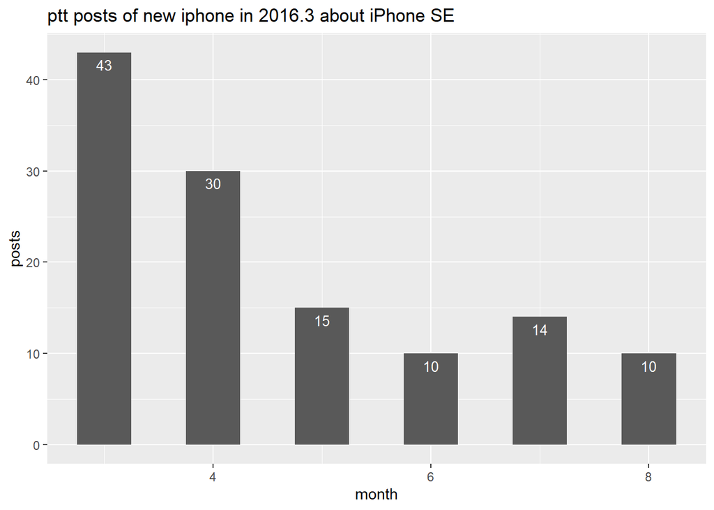

```r
library(ggplot2)
ggplot(data=iphone_2016_3, aes(x=month,y=posts))+
       geom_bar(stat="identity",width=0.5)+
       ggtitle("ptt posts of new iphone in 2016.3 about iPhone SE")+
       geom_text(aes(label=posts), vjust=1.6, color="white", size=3.5)
```

## 2015-9-25 iPhone 6s,iPhone 6s plus

### 一、爬出ptt-iphone-mobliecomm文章標題

**遇到的困難:1.如何使用迴圈抓網頁標題?/2.抓取非html網址**

```r
library(rvest)

pttMobileComm_4 <- data.frame()

for(iD in 19:11) #2015.8.11-2015.12.30
{
  prefix <- "https://www.ptt.cc/bbs/MobileComm/search?page="
  url  <- paste0( prefix, as.character(iD), "&q=iphone+6s" )

  iphone <- read_html(url)
  post_title <- iphone%>%
    html_nodes(".title") %>%
    html_text()
  post_date <- iphone %>%
    html_nodes(".date") %>%
    html_text()

  pttMobileComm_4 <- rbind(pttMobileComm_4, data.frame(title= post_title,
                                                    date= post_date))
}

library(knitr)
kable(head(pttMobileComm_4))
```

| title | date |
| --- | --- |
| [新聞] iPhone 6s自拍相機傳畫素增3倍，售價不變 | 8/31 |
| [新聞] 消息確認！ iPhone 6S將推「玫瑰金」款式 | 8/31 |
| [情報] 董俊良：iPhone 6S換機高峰已過 HTC將以 | 8/30 |
| [新聞] iPhone 6s 傳電池容量縮水，不會增加新色 | 8/27 |
| [新聞] iPhone 6s 機身變厚0.2mm 但背後相機仍凸 | 8/27 |
| [問題] 等iPhone 6S 或 iPod touch 6 + Z3+ | 8/11 |

### 二、依照month合併儲存

**遇到的困難:1.如何依照月份儲存資料/2.factor->string**

```r
library(magrittr)
library(dplyr)
library(lubridate)
iphone_data7 <- pttMobileComm_4 %>%
  mutate(date=as.character(date)) %>%
  mutate(month= month(as.POSIXlt(date, format="%m/%d")))

library(knitr)
kable(head(iphone_data7))
```

| title | date | month |
| --- | --- | --- |
| [新聞] iPhone 6s自拍相機傳畫素增3倍，售價不變 | 8/31 | 8 |
| [新聞] 消息確認！ iPhone 6S將推「玫瑰金」款式 | 8/31 | 8 |
| [情報] 董俊良：iPhone 6S換機高峰已過 HTC將以 | 8/30 | 8 |
| [新聞] iPhone 6s 傳電池容量縮水，不會增加新色 | 8/27 | 8 |
| [新聞] iPhone 6s 機身變厚0.2mm 但背後相機仍凸 | 8/27 | 8 |
| [問題] 等iPhone 6S 或 iPod touch 6 + Z3+ | 8/11 | 8 |

```r
iphone_data8 <-iphone_data7 %>% count(month)
iphone_2015 <- iphone_data8[-c(1:4),]
iphone_2015
```

```
## # A tibble: 5 x 2
##   month     n
##   <dbl> <int>
## 1     8     6
## 2     9    47
## 3    10    76
## 4    11    17
## 5    12    20
```

### 三、作圖

```r
colnames(iphone_2015) <- c("month", "posts")
iphone_2015
```

```
## # A tibble: 5 x 2
##   month posts
##   <dbl> <int>
## 1     8     6
## 2     9    47
## 3    10    76
## 4    11    17
## 5    12    20
```

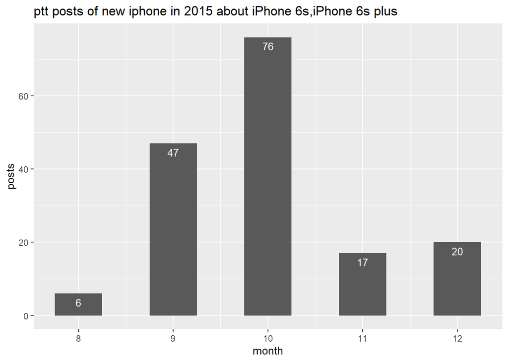

```r
library(ggplot2)
ggplot(data=iphone_2015, aes(x=month,y=posts))+
       geom_bar(stat="identity",width=0.5)+
       ggtitle("ptt posts of new iphone in 2015 about iPhone 6s,iPhone 6s plus")+
       geom_text(aes(label=posts), vjust=1.6, color="white", size=3.5)
```

### 結論:2007-2015都是每年推出一次，觀察2015年，熱潮持續近2個月。2016年，3月先推出iphone SE，隔半年才推出另一系列iphone7&7+，推出日期不太接近，只有在上市當月引起討論，不易形成一股風潮。發現推出新手機款式的日期越接近(如2017&2018年)，因為互相比較，會引發群眾討論，話題熱潮長-大概持續2-3個月，話題討論數量也比較多。